# task15

MildaPie

2016 m lapkritis 10 d

# Tiesinė regresija

## Užduotis

Jums reikia atlikti paprastą tiesinę regresiją. Prognozuojamas kintamasis y, regresosrius x. Duomenų failas: https://github.com/1vbutkus/Econometrics1/blob/master/task15/data.csv 1. Įvertinti paprastosios tiesinės regresijos modelį. Pateikti modelio `summary` ir pakomentuoti ką reiškia gauti skaičiai. Kaip interpretuoti gautus rezultatus? 2. Padarykite modelio prognozes taškuose $0, 0.3, 0.5$. 3. Išbrėžkite kintamųjų sklaidos diagramą kartu su tiesinės regresijos tiese ir naujomis prognozėmis. Grafiką pateikite su pilna legena, kurioje būtų nurodyti visi žymėjimai. 4. Pakomentuokite ar tinkamas šis modelis duotiems duomenims. Ar galite pateikti tobulinimo pasiūlymų?

## Sprendimas

1. Įvertinti paprastosios tiesinės regresijos modelį. Pateikti modelio `summary` ir pakomentuoti ką reiškia gauti skaičiai. Kaip interpretuoti gautus rezultatus?

```r
dt<-read.csv("https://raw.githubusercontent.com/1vbutkus/Econometrics1/master/task15/data.csv")


dt.lm <- lm(y ~ x, data = dt)

 summary(lm(y ~ x, dt))
```

```
##
## Call:
## lm(formula = y ~ x, data = dt)
##
## Residuals:
##      Min       1Q   Median       3Q      Max
## -0.14936 -0.08639 -0.04626  0.08815  0.21943
##
## Coefficients:
##             Estimate Std. Error t value Pr(>|t|)
## (Intercept)  2.06843    0.01205  171.58   <2e-16 ***
## x            0.50934    0.03225   15.79   <2e-16 ***
## ---
## Signif. codes:  0 '***' 0.001 '**' 0.01 '*' 0.05 '.' 0.1 ' ' 1
##
## Residual standard error: 0.1065 on 98 degrees of freedom
## Multiple R-squared:  0.7179, Adjusted R-squared:  0.715
## F-statistic: 249.4 on 1 and 98 DF,  p-value: < 2.2e-16
```

Residuals - nusako skirtumą tarp kintamojo tikrųjų reikšmių ir ir regresijos nustatytų. Daugeliu atvejų reikia, kad residuals primintų normalūjų skirstinį.

Signif codes - žvaigždutės atitinka p reikšmę. *** reiškia, kad nedidelė tikimybė, jog nėra priklausomybės tarp y ir x.

Estimated coefficient- regresija įvertintas krypties koeficientas.

Standard error - matuoja koeficiento įverčio variaciją. Kuo mažesnis, tuo geriau. (Turėtų būti mažesnis, nei coefficient estimate)

residual standard error- residuals standartinis nuokrypis. Turėtų būti proporcingas kvantiliams prie Residuals. Multiple R-squared- matuoja goodness of fit. Kuo didesnis tuo geriau (iki 1). F-statistic- F testo rezultatas. Tikrina, ar modelis su daugiau parametrų (dabartinis) geresnis, nei su mažiau.

2. Padarykite modelio prognozes taškuose $0, 0.3, 0.5$.

```r
dt.lm <- lm(y ~ x, data = dt)
predict(dt.lm,newdata=data.frame(x=c(0,0.3,0.5)))
```

```
##        1        2        3
## 2.068428 2.221230 2.323098
```

3. Išbrėžkite kintamųjų sklaidos diagramą kartu su tiesinės regresijos tiese ir naujomis prognozėmis. Grafiką pateikite su pilna legena, kurioje būtų nurodyti visi žymėjimai.

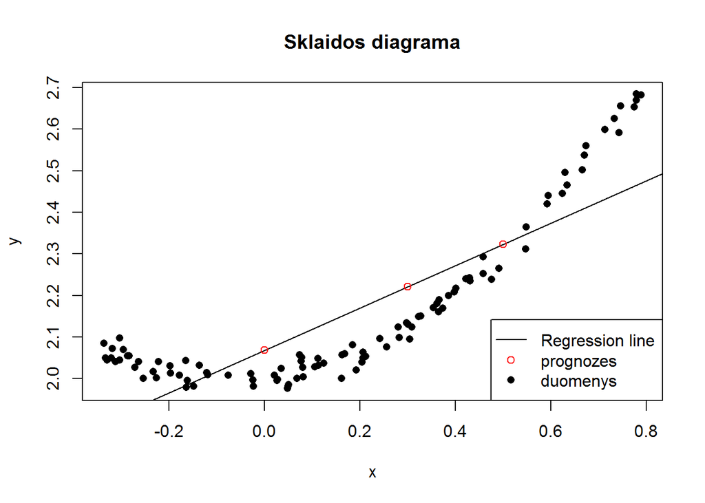

```r
dt.lm <- lm(y ~ x, data = dt)
 plot(y ~ x, data = dt, pch=16, main="Sklaidos diagrama", xlab="x", ylab = "y")
 abline(coef(dt.lm))
 predict(dt.lm, newdata=data.frame(x=c(0,0.3,0.5)))->pre

 points(c(0,0.3,0.5), pre, col=2)
 legend("bottomright", legend = c("Regression line","prognozes", "duomenys" ), col = c(1,2,1), lty = c(1,NA,NA), pch=c(NA, 1, 16) )
```

4. Pakomentuokite ar tinkamas šis modelis duotiems duomenims. Ar galite pateikti tobulinimo pasiūlymų?

Atrodo, kad modelis netinkamas. Duomenų sklaida neprimena tiesės.

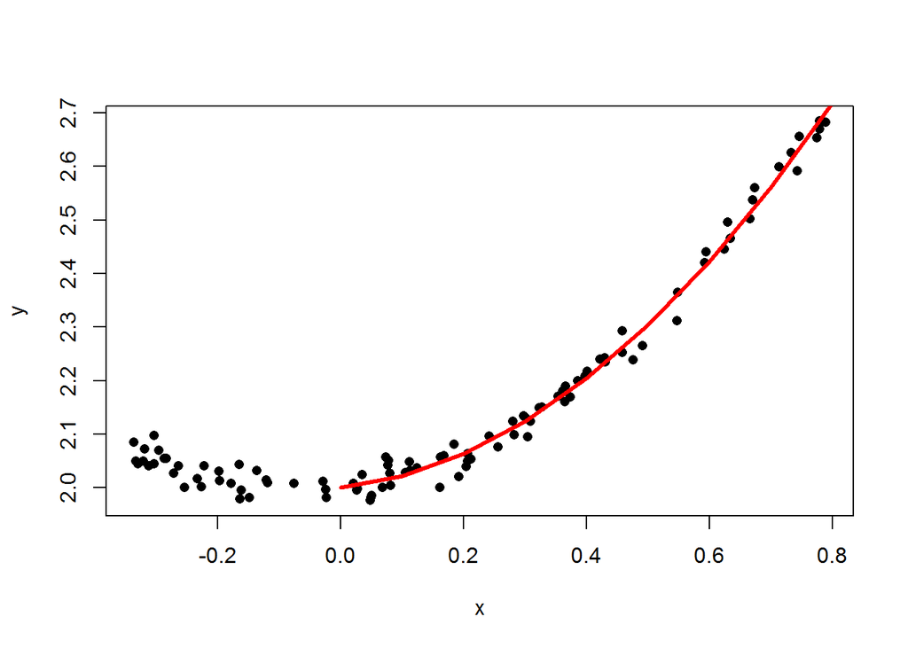

```r
 x<-dt$x
 y<-dt$y
x2<-x^2

quadratic.model<-lm(y~x+x2)
xvalues<-seq(0,30,0.1)
predictedcounts<-predict(quadratic.model, list(x=xvalues, x2=xvalues^2))
plot(x, y, pch=16, xlab="x", ylab="y")
lines(xvalues, predictedcounts, col=2, lwd=3)
```

### Literatūra:

https://github.com/MildaPie/Econometrics1/tree/master/task11

http://www.theanalysisfactor.com/r-tutorial-4/

http://blog.yhat.com/posts/r-lm-summary.html